# Final_AllLife_Bank_Project

#### Predicting on Train Set

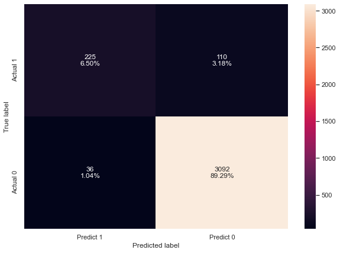

```python
# let us make confusion matrix on train set
make_confusion_matrix(y_train,pred_train)
plt.savefig('CMTrain_Plot.png')
plt.show()
```

#### Predicting on Test Set

```
confusion matrix =
```

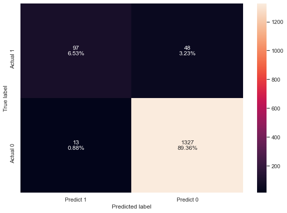

```python
#Predict for test set
pred_test = lr.predict(X_test)

print("confusion matrix = \n")
make_confusion_matrix(y_test,pred_test)
plt.savefig('CMTest_Plt.png')
plt.show()
```

```python
lr = LogisticRegression(solver='newton-cg',random_state=1,fit_intercept=False)
model  = lr.fit(X_train,y_train)

# Let's check model performances for this model
scores_LR = get_metrics_score2(model,X_train,X_test,y_train,y_test)
```

```
Accuracy on training set :  0.9572624891712388
Accuracy on test set :  0.9555555555555556
Recall on training set :  0.6597014925373135
Recall on test set :  0.6413793103448275
Precision on training set :  0.8666666666666667
Precision on test set :  0.8691588785046729
F1 on training set :  0.7491525423728814
F1 on test set :  0.738095238095238
```

- We have build a logistic regression model which shows good performance on the train and test sets but to identify significant variables we will have to build a logistic regression model using the statsmodels library.

### Logistic Regression (with statsmodels library)

- Using statsmodels, we will be able to check the statistical validity of our model - identify the significant predictors from p-values that we get for each predictor variable.

```python
import statsmodels.api as sm
logit = sm.Logit(y_train, X_train.astype(float))
lg = logit.fit(warn_convergence =False)

# Let's check model performances for this model
scores_LR = get_metrics_score1(lg,X_train,X_test,y_train,y_test)
```

```
Optimization terminated successfully.
         Current function value: 0.118555
         Iterations 9
Accuracy on training set :  0.9578400231013572
Accuracy on test set :  0.958922558922559
Recall on training set :  0.6716417910447762
Recall on test set :  0.6689655172413793
Precision on training set :  0.8620689655172413
Precision on test set :  0.8818181818181818
F1 on training set :  0.7550335570469799
F1 on test set :  0.7607843137254902
```

```python
lg.summary()
```

Logit Regression Results

| Dep. Variable: | Personal_Loan | No. Observations: | 3463 |
| --- | --- | --- | --- |
| Model: | Logit | Df Residuals: | 3450 |
| Method: | MLE | Df Model: | 12 |
| Date: | Fri, 11 Jun 2021 | Pseudo R-squ.: | 0.6270 |
| Time: | 23:45:15 | Log-Likelihood: | -410.56 |
| converged: | True | LL-Null: | -1100.7 |
| Covariance Type: | nonrobust | LLR p-value: | 2.408e-288 |

|  | coef | std err | z | P>\|z\| | [0.025 | 0.975] |
| --- | --- | --- | --- | --- | --- | --- |
| const | -7.6903 | 2.177 | -3.533 | 0.000 | -11.957 | -3.424 |
| Age | -0.0528 | 0.081 | -0.649 | 0.516 | -0.212 | 0.107 |
| Experience | 0.0631 | 0.081 | 0.778 | 0.437 | -0.096 | 0.222 |
| Income | 0.0586 | 0.004 | 16.532 | 0.000 | 0.052 | 0.066 |
| Family | 0.5797 | 0.092 | 6.271 | 0.000 | 0.398 | 0.761 |
| CCAvg | 0.1735 | 0.053 | 3.266 | 0.001 | 0.069 | 0.278 |
| Mortgage | 0.0011 | 0.001 | 1.576 | 0.115 | -0.000 | 0.002 |
| Education_Graduate | -0.0594 | 0.226 | -0.263 | 0.793 | -0.502 | 0.383 |
| Education_Undergrad | -3.8927 | 0.315 | -12.348 | 0.000 | -4.511 | -3.275 |
| Securities_Account_1 | -0.7773 | 0.361 | -2.150 | 0.032 | -1.486 | -0.069 |
| CD_Account_1 | 3.8776 | 0.418 | 9.271 | 0.000 | 3.058 | 4.697 |
| Online_1 | -0.7426 | 0.197 | -3.769 | 0.000 | -1.129 | -0.356 |
| CreditCard_1 | -1.1665 | 0.260 | -4.481 | 0.000 | -1.677 | -0.656 |

Possibly complete quasi-separation: A fraction 0.10 of observations can be  
perfectly predicted. This might indicate that there is complete  
quasi-separation. In this case some parameters will not be identified.

### Treating Multicollinearity using VIF scores

```python
# To check for Multicollinearity we import the Variance Inflation Factor
from statsmodels.stats.outliers_influence import variance_inflation_factor
from statsmodels.tools.tools import add_constant
# changing datatype of colums to numeric for checking vif
x_train_num = X_train.astype(float).copy()
x_train_num = add_constant(x_train_num)
```

```python
vif_series1 = pd.Series([variance_inflation_factor(x_train_num.values,i) for i in range(x_train_num.shape[1])],index=x_train_num.columns, dtype = float)
print('Series before feature selection: \n\n{}\n'.format(vif_series1))
```

```
Series before feature selection:

const                   492.457351
Age                      91.825287
Experience               91.740122
Income                    1.910235
Family                    1.047084
CCAvg                     1.782189
Mortgage                  1.050374
Education_Graduate        1.434809
Education_Undergrad       1.549320
Securities_Account_1      1.137455
CD_Account_1              1.316021
Online_1                  1.036606
CreditCard_1              1.104752
dtype: float64
```

- With a VIF score greater than 5, the collinearity between Age and Experience is obvious

### Dropping Experience

```python
x_train_num1 = x_train_num.drop('Experience',axis=1)
vif_series2 = pd.Series([variance_inflation_factor(x_train_num1.values,i) for i in range(x_train_num1.shape[1])],index=x_train_num1.columns)
print('Series before feature selection: \n\n{}\n'.format(vif_series2))
```

```
Series before feature selection:

const                   31.807206
Age                      1.011148
Income                   1.905255
Family                   1.043993
CCAvg                    1.774659
Mortgage                 1.050051
Education_Graduate       1.415291
Education_Undergrad      1.456071
Securities_Account_1     1.137115
CD_Account_1             1.315106
Online_1                 1.036601
CreditCard_1             1.104750
dtype: float64
```

- Removal of Experience has fixed Multicollinearity in the dataset

#### Now lets create a model with all the features except Experience

```python
X_train,X_test,y_train,y_test = split('Personal_Loan')
```

```python
X_train.drop(['Experience'],axis=1,inplace=True)
X_test.drop(['Experience'],axis=1,inplace=True)
```

```python
logit1 = sm.Logit(y_train, X_train.astype(float))
lg1 = logit1.fit(warn_convergence =False)

# Let's check model performances for this model
scores_LR = get_metrics_score1(lg1,X_train,X_test,y_train,y_test)
```

```
Optimization terminated successfully.
         Current function value: 0.118644
         Iterations 9
Accuracy on training set :  0.9584175570314756
Accuracy on test set :  0.958922558922559
Recall on training set :  0.6716417910447762
Recall on test set :  0.6689655172413793
Precision on training set :  0.8687258687258688
Precision on test set :  0.8818181818181818
F1 on training set :  0.7575757575757576
F1 on test set :  0.7607843137254902
```

```python
print(lg1.summary())
```

```
                           Logit Regression Results
==============================================================================
Dep. Variable:          Personal_Loan   No. Observations:                 3463
Model:                          Logit   Df Residuals:                     3451
Method:                           MLE   Df Model:                           11
Date:                Fri, 11 Jun 2021   Pseudo R-squ.:                  0.6267
Time:                        23:45:15   Log-Likelihood:                -410.87
converged:                       True   LL-Null:                       -1100.7
Covariance Type:            nonrobust   LLR p-value:                2.854e-289
========================================================================================
                           coef    std err          z      P>|z|      [0.025      0.975]
----------------------------------------------------------------------------------------
const                   -9.3107      0.667    -13.963      0.000     -10.618      -8.004
Age                      0.0102      0.008      1.236      0.216      -0.006       0.026
Income                   0.0587      0.004     16.602      0.000       0.052       0.066
Family                   0.5778      0.092      6.254      0.000       0.397       0.759
CCAvg                    0.1733      0.053      3.263      0.001       0.069       0.277
Mortgage                 0.0011      0.001      1.540      0.124      -0.000       0.002
Education_Graduate      -0.0351      0.224     -0.157      0.876      -0.474       0.404
Education_Undergrad     -3.8583      0.312    -12.369      0.000      -4.470      -3.247
Securities_Account_1    -0.7648      0.360     -2.122      0.034      -1.471      -0.058
CD_Account_1             3.8798      0.418      9.282      0.000       3.061       4.699
Online_1                -0.7322      0.196     -3.728      0.000      -1.117      -0.347
CreditCard_1            -1.1626      0.260     -4.468      0.000      -1.673      -0.653
========================================================================================

Possibly complete quasi-separation: A fraction 0.10 of observations can be
perfectly predicted. This might indicate that there is complete
quasi-separation. In this case some parameters will not be identified.
```

#### Dropping Mortgage by p-value

```python
x_train_num2 = x_train_num1.drop('Mortgage',axis=1)
vif_series3 = pd.Series([variance_inflation_factor(x_train_num2.values,i) for i in range(x_train_num2.shape[1])],index=x_train_num2.columns)
print('Series before feature selection: \n\n{}\n'.format(vif_series3))
```

```
Series before feature selection:

const                   31.711555
Age                      1.011136
Income                   1.848276
Family                   1.043942
CCAvg                    1.769521
Education_Graduate       1.415289
Education_Undergrad      1.455979
Securities_Account_1     1.136553
CD_Account_1             1.309100
Online_1                 1.035854
CreditCard_1             1.103571
dtype: float64
```

```python
X_train1,X_test1,y_train,y_test = split('Personal_Loan','Mortgage')
```

```python
X_train1.drop(['Experience'],axis=1,inplace=True)
X_test1.drop(['Experience'],axis=1,inplace=True)
```

```python
logit2 = sm.Logit(y_train, X_train1.astype(float))
lg2 = logit2.fit(warn_convergence =False)

# Let's check model performances for this model
scores_LR = get_metrics_score1(lg2,X_train1,X_test1,y_train,y_test,flag=True)
```

```
Optimization terminated successfully.
         Current function value: 0.118984
         Iterations 9
Accuracy on training set :  0.9572624891712388
Accuracy on test set :  0.9582491582491582
Recall on training set :  0.6686567164179105
Recall on test set :  0.6689655172413793
Precision on training set :  0.8582375478927203
Precision on test set :  0.8738738738738738
F1 on training set :  0.7516778523489934
F1 on test set :  0.7578125
```

```python
print(lg2.summary())
```

```
                           Logit Regression Results
==============================================================================
Dep. Variable:          Personal_Loan   No. Observations:                 3463
Model:                          Logit   Df Residuals:                     3452
Method:                           MLE   Df Model:                           10
Date:                Fri, 11 Jun 2021   Pseudo R-squ.:                  0.6257
Time:                        23:45:16   Log-Likelihood:                -412.04
converged:                       True   LL-Null:                       -1100.7
Covariance Type:            nonrobust   LLR p-value:                7.616e-290
========================================================================================
                           coef    std err          z      P>|z|      [0.025      0.975]
----------------------------------------------------------------------------------------
const                   -9.2614      0.665    -13.931      0.000     -10.564      -7.958
Age                      0.0098      0.008      1.187      0.235      -0.006       0.026
Income                   0.0594      0.004     16.842      0.000       0.052       0.066
Family                   0.5814      0.093      6.283      0.000       0.400       0.763
CCAvg                    0.1601      0.053      3.050      0.002       0.057       0.263
Education_Graduate      -0.0259      0.223     -0.116      0.908      -0.464       0.412
Education_Undergrad     -3.8209      0.310    -12.333      0.000      -4.428      -3.214
Securities_Account_1    -0.7634      0.361     -2.115      0.034      -1.471      -0.056
CD_Account_1             3.9004      0.419      9.319      0.000       3.080       4.721
Online_1                -0.7371      0.196     -3.760      0.000      -1.121      -0.353
CreditCard_1            -1.1712      0.260     -4.509      0.000      -1.680      -0.662
========================================================================================
```

#### Dropping Age

```python
x_train_num3 = x_train_num2.drop('Age',axis=1)
vif_series4 = pd.Series([variance_inflation_factor(x_train_num3.values,i) for i in range(x_train_num3.shape[1])],index=x_train_num3.columns)
print('Series before feature selection: \n\n{}\n'.format(vif_series4))
```

```
Series before feature selection:

const                   12.994947
Income                   1.846278
Family                   1.041502
CCAvg                    1.767728
Education_Graduate       1.412747
Education_Undergrad      1.454009
Securities_Account_1     1.136435
CD_Account_1             1.308118
Online_1                 1.035815
CreditCard_1             1.103555
dtype: float64
```

```python
X_train2,X_test2,y_train,y_test = split('Personal_Loan','Age')
```

```python
X_train2.drop(['Experience','Mortgage'],axis=1,inplace=True)
X_test2.drop(['Experience','Mortgage'],axis=1,inplace=True)
```

```python
logit3 = sm.Logit(y_train, X_train2.astype(float))
lg3 = logit3.fit(warn_convergence =False)

# Let's check model performances for this model
scores_LR = get_metrics_score1(lg3,X_train2,X_test2,y_train,y_test,flag=True)
```

```
Optimization terminated successfully.
         Current function value: 0.119188
         Iterations 9
Accuracy on training set :  0.9578400231013572
Accuracy on test set :  0.9595959595959596
Recall on training set :  0.6716417910447762
Recall on test set :  0.6758620689655173
Precision on training set :  0.8620689655172413
Precision on test set :  0.8828828828828829
F1 on training set :  0.7550335570469799
F1 on test set :  0.7656250000000001
```

### This is the Metrics of the final model lg3

```python
print(lg3.summary())
```

```
                           Logit Regression Results
==============================================================================
Dep. Variable:          Personal_Loan   No. Observations:                 3463
Model:                          Logit   Df Residuals:                     3453
Method:                           MLE   Df Model:                            9
Date:                Fri, 11 Jun 2021   Pseudo R-squ.:                  0.6250
Time:                        23:45:16   Log-Likelihood:                -412.75
converged:                       True   LL-Null:                       -1100.7
Covariance Type:            nonrobust   LLR p-value:                1.209e-290
========================================================================================
                           coef    std err          z      P>|z|      [0.025      0.975]
----------------------------------------------------------------------------------------
const                   -8.7730      0.514    -17.074      0.000      -9.780      -7.766
Income                   0.0591      0.004     16.838      0.000       0.052       0.066
Family                   0.5782      0.093      6.249      0.000       0.397       0.760
CCAvg                    0.1535      0.052      2.928      0.003       0.051       0.256
Education_Graduate      -0.0261      0.223     -0.117      0.907      -0.463       0.411
Education_Undergrad     -3.8119      0.309    -12.321      0.000      -4.418      -3.205
Securities_Account_1    -0.7634      0.360     -2.118      0.034      -1.470      -0.057
CD_Account_1             3.9037      0.418      9.333      0.000       3.084       4.724
Online_1                -0.7327      0.196     -3.741      0.000      -1.117      -0.349
CreditCard_1            -1.1651      0.260     -4.486      0.000      -1.674      -0.656
========================================================================================
```

### Observation

##### Insights on Co-efficients

  ```
    Probability = odd/(1+odd)
    So we can say for a one-unit increase in a co-efficient will lead to a proportional increase in
    the target variable and vice versa
  ```

### ROC Curve

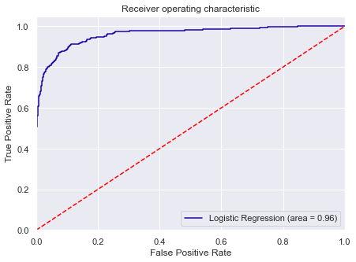

```python
from sklearn.metrics import roc_curve

logit_roc_auc_train = roc_auc_score(y_train, lg3.predict(X_train2))

fpr, tpr, thresholds = roc_curve(y_train, lg3.predict(X_train2))

plt.figure(figsize=(7,5))

plt.plot(fpr, tpr, label='Logistic Regression (area = %0.2f)' % logit_roc_auc_train)
plt.plot([0, 1], [0, 1],'r--')
plt.xlim([0.0, 1.0])
plt.ylim([0.0, 1.05])
plt.xlabel('False Positive Rate')
plt.ylabel('True Positive Rate')
plt.title('Receiver operating characteristic')
plt.legend(loc="lower right")
plt.savefig('RoCTrain_plt.png')
plt.show()
```

- AUC-ROC on Train Set

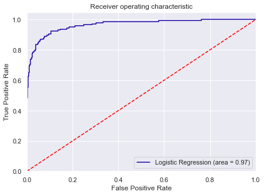

```python
logit_roc_auc_test = roc_auc_score(y_test, lg3.predict(X_test2))
fpr, tpr, thresholds = roc_curve(y_test, lg3.predict(X_test2))
plt.figure(figsize=(7,5))
plt.plot(fpr, tpr, label='Logistic Regression (area = %0.2f)' % logit_roc_auc_test)
plt.plot([0, 1], [0, 1],'r--')
plt.xlim([0.0, 1.0])
plt.ylim([0.0, 1.05])
plt.xlabel('False Positive Rate')
plt.ylabel('True Positive Rate')
plt.title('Receiver operating characteristic')
plt.legend(loc="lower right")
plt.savefig("RoCTest_plt.png")
plt.show()
```

- AUC-ROC on Test set

#### Logistic Regression model is giving a generalized performance on training and test set.

### Model Performance Improvement

### Optimal Threshold

```python
# Optimal threshold as per AUC-ROC curve
# The optimal cut off would be where tpr is high and fpr is low
fpr, tpr, thresholds = metrics.roc_curve(y_test, lg3.predict(X_test2))

optimal_idx = np.argmax(tpr - fpr) #argmax Returns the indices of the maximum values along an axis.
optimal_threshold_auc_roc = thresholds[optimal_idx]
print(optimal_threshold_auc_roc)
```

```
0.08282297498154194
```

```python
scores_LR = get_metrics_score1(lg3,X_train2,X_test2,y_train,y_test,threshold=optimal_threshold_auc_roc,roc=True)
```

```
Accuracy on training set :  0.8896910193473867
Accuracy on test set :  0.8962962962962963
Recall on training set :  0.9104477611940298
Recall on test set :  0.9172413793103448
Precision on training set :  0.4642313546423135
Precision on test set :  0.48363636363636364
F1 on training set :  0.6149193548387096
F1 on test set :  0.6333333333333333
ROC-AUC Score on training set :  0.8989578959422835
ROC-AUC Score on test set :  0.9056356150283067
```

- We can see here that the Precision and F1 scores reduced but the Recall score greatly improved by changing the model threshold

```python
target_names = ['Predict 1', 'Predict 0']
y_pred_tr = (lg3.predict(X_train2)>optimal_threshold_auc_roc).astype(int)
y_pred_ts = (lg3.predict(X_test2)>optimal_threshold_auc_roc).astype(int)
```

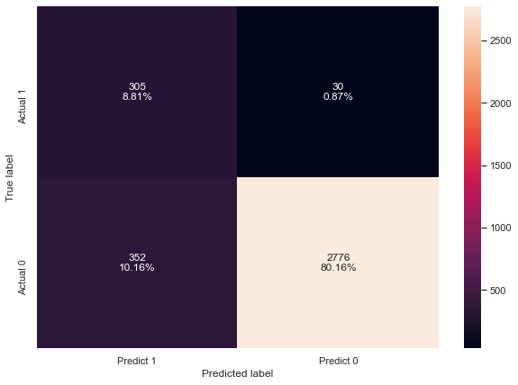

```python
make_confusion_matrix(y_train,y_pred_tr )
plt.savefig('Pred_Train_Opt.png')
plt.show()
```

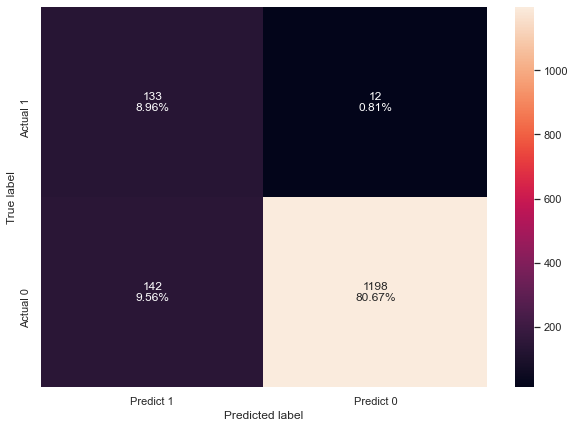

```python
make_confusion_matrix(y_test,y_pred_ts)
plt.savefig('Pred_Test_Opt.png')
plt.show()
```

### Observation

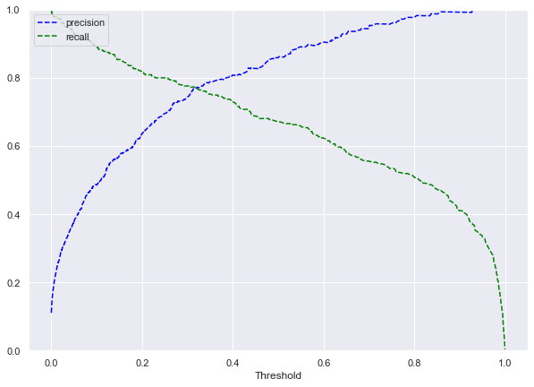

```python
## Using Precision-Recall to see if we can get a better Threshold
from sklearn.metrics import precision_recall_curve
y_scores=lg3.predict(X_train2)
prec, rec, tre = precision_recall_curve(y_train, y_scores,)

def plot_prec_recall_vs_tresh(precisions, recalls, thresholds):
    plt.plot(thresholds, precisions[:-1], 'b--', label='precision')
    plt.plot(thresholds, recalls[:-1], 'g--', label = 'recall')
    plt.xlabel('Threshold')
    plt.legend(loc='upper left')
    plt.ylim([0,1])
plt.figure(figsize=(10,7))
plot_prec_recall_vs_tresh(prec, rec, tre)
plt.savefig('Prec_Recplt.png')
plt.show()
```

- At the threshold of 0.32, we get balanced recall and precision.

```python
optimal_threshold_curve = 0.32

scores_LR = get_metrics_score1(lg3,X_train2,X_test2,y_train,y_test,threshold=optimal_threshold_curve,roc=True)
```

```
Accuracy on training set :  0.9555298873808836
Accuracy on test set :  0.9575757575757575
Recall on training set :  0.7701492537313432
Recall on test set :  0.7724137931034483
Precision on training set :  0.7701492537313432
Precision on test set :  0.7887323943661971
F1 on training set :  0.7701492537313432
F1 on test set :  0.7804878048780487
ROC-AUC Score on training set :  0.8727664427224492
ROC-AUC Score on test set :  0.8750128667009779
```

- At the threshold of 0.32 we get a balanced Recall and Precision score

### Converting coefficients to odds

- The coefficients of the logistic regression model are in terms of log(odd), to find the odds we have to take the exponential of the coefficients.
- Therefore, **odds = exp(b)**
- The percentage change in odds is given as **odds = (exp(b) - 1) * 100**

```python
#Calculate Odds Ratio, probability
##create a data frame to collate Odds ratio, probability and p-value of the coef
lgcoef = pd.DataFrame(lg3.params, columns=['coef'])
lgcoef.loc[:, "Odds_ratio"] = np.exp(lgcoef.coef)
lgcoef['probability'] = lgcoef['Odds_ratio']/(1+lgcoef['Odds_ratio'])
lgcoef['pval']=lg.pvalues
pd.options.display.float_format = '{:.2f}'.format
```

```python
# Filter by significant p-value (pval <0.005) and sort descending by Odds ratio
lgcoef = lgcoef.sort_values(by="Odds_ratio", ascending=False)
pval_filter = lgcoef['pval']<=0.005
lgcoef[pval_filter]
```

|  | coef | Odds_ratio | probability | pval |
| --- | --- | --- | --- | --- |
| CD_Account_1 | 3.90 | 49.59 | 0.98 | 0.00 |
| Family | 0.58 | 1.78 | 0.64 | 0.00 |
| CCAvg | 0.15 | 1.17 | 0.54 | 0.00 |
| Income | 0.06 | 1.06 | 0.51 | 0.00 |
| Online_1 | -0.73 | 0.48 | 0.32 | 0.00 |
| CreditCard_1 | -1.17 | 0.31 | 0.24 | 0.00 |
| Education_Undergrad | -3.81 | 0.02 | 0.02 | 0.00 |
| const | -8.77 | 0.00 | 0.00 | 0.00 |

### Insight

- Liability customers with a high CD_ Account has a 98% chance of being offered a personal loan
- Smilarly, a liability customer with a high income has a 51% shot at a personal loan offer
- Equally, a cusomer with a high credit card spending average, has a 54% potential of being offered a loan
- Also, an undergraduate customer has a 2% chance of a shot at a personal loan offer. Very highly unlikely
- Percualiar interpretations are rife for other variables

### Establishing the Most Significant Variable

```python
# we are looking are overall significant varaible
pval_filter = lgcoef['pval']<=0.0001
imp_vars = lgcoef[pval_filter].index.tolist()

# we are going to get overall varaibles (un-one-hot encoded varables) from categorical varaibles
sig_var = []
for col in imp_vars:
    if '_' in col:
        first_part = col.split('_')[0]
        for c in df.columns:
            if first_part in c and c not in sig_var :
                sig_var.append(c)


start = '\033[1m'
end = '\033[95m'
print('Most significant varaibles category wise are :\n',lgcoef[pval_filter].index.tolist())
print('*'*120)

print(start+'Most overall significant varaibles  are '+end,':\n',sig_var)
```

```
Most significant varaibles category wise are :
 ['CD_Account_1', 'Family', 'Income', 'CreditCard_1', 'Education_Undergrad']
Most overall significant varaibles  are  :
 ['CD_Account', 'CreditCard', 'Education']
```

### Model Performance Summary

```python
# defining list of model
models = [lg3]

# defining empty lists to add train and test results
acc_train = []
acc_test = []
recall_train = []
recall_test = []
precision_train = []
precision_test = []
f1_train = []
f1_test = []

# looping through the models list to get the metrics score - Accuracy, Recall, Precision, and F1 score
for model in models:

    j = get_metrics_score1(model,X_train2,X_test2,y_train,y_test,flag=False)
    acc_train.append(j[0])
    acc_test.append(j[1])
    recall_train.append(j[2])
    recall_test.append(j[3])
    precision_train.append(j[4])
    precision_test.append(j[5])
    f1_train.append(j[6])
    f1_test.append(j[7])
```

```python
# defining list of model
models = [lg3]

# looping through the models list to get the metrics score - Accuracy, Recall, Precision, and F1 score
for model in models:

    j = get_metrics_score1(model,X_train2,X_test2,y_train,y_test,threshold=optimal_threshold_auc_roc,flag=False)
    acc_train.append(j[0])
    acc_test.append(j[1])
    recall_train.append(j[2])
    recall_test.append(j[3])
    precision_train.append(j[4])
    precision_test.append(j[5])
    f1_train.append(j[6])
    f1_test.append(j[7])
```

```python
# defining list of model
models = [lg3]

# looping through the models list to get the metrics score - Accuracy, Recall, Precision, and F1 score
for model in models:

    j = get_metrics_score1(model,X_train2,X_test2,y_train,y_test,threshold=optimal_threshold_curve,flag=False)
    acc_train.append(j[0])
    acc_test.append(j[1])
    recall_train.append(j[2])
    recall_test.append(j[3])
    precision_train.append(j[4])
    precision_test.append(j[5])
    f1_train.append(j[6])
    f1_test.append(j[7])
```

```python
comparison_frame = pd.DataFrame({'Model':['Logistic Regression Model - Statsmodels',
                                          'Logistic Regression - Optimal threshold = 0 .08',
                                          'Logistic Regression - Optimal threshold = 0 .32'
                                          ],
                                          'Train_Accuracy':acc_train,
                                          'Test_Accuracy':acc_test,
                                          'Train Recall':recall_train,
                                          'Test Recall':recall_test,
                                          'Train Precision':precision_train,
                                          'Test Precision':precision_test,
                                          'Train F1':f1_train,
                                          'Test F1':f1_test
                                })


comparison_frame
```

|  | Model | Train_Accuracy | Test_Accuracy | Train Recall | Test Recall | Train Precision | Test Precision | Train F1 | Test F1 |
| --- | --- | --- | --- | --- | --- | --- | --- | --- | --- |
| 0 | Logistic Regression Model - Statsmodels | 0.96 | 0.96 | 0.67 | 0.68 | 0.86 | 0.88 | 0.76 | 0.77 |
| 1 | Logistic Regression - Optimal threshold = 0 .08 | 0.89 | 0.90 | 0.91 | 0.92 | 0.46 | 0.48 | 0.61 | 0.63 |
| 2 | Logistic Regression - Optimal threshold = 0 .32 | 0.96 | 0.96 | 0.77 | 0.77 | 0.77 | 0.79 | 0.77 | 0.78 |

### Conclusion

- We have been able to build a predictive model that can be used by the AllLife Bank to target potential personal loan purchasers an f1_score of 0.77 on the training set and formulate marketing strategies accordingly as well as allocate scarce resources toward maximising profit via fees accordingly. (Statsmodels - Logistic Regression - with significant predictors).
- Coefficients of some levels of Income, CCAvg, CD_Account, Family are positive for which an increase in these will lead to a proportional increase in chances of being offered a personal loan
- Coefficients of Undergraduate Education,Online Banking, Credit card, are negative increase in these will lead to adecrease in chances of a liability customer getting a personal loan

## CART (DECISION TREE MODEL)

### Preamble

- We will build our model using the DecisionTreeClassifier function. Using default 'gini' criteria to split.
- If the frequency of class A is 10% and the frequency of class B is 90%, then class B will become the dominant class and the decision tree will become biased toward the dominant classes.
- In this case, we can pass a dictionary {0:0.15,1:0.85} to the model to specify the weight of each class and the decision tree will give more weightage to class 1.
- class_weight is a hyperparameter for the decision tree classifier.

```python
model = DecisionTreeClassifier(criterion='gini',class_weight={0:0.15,1:0.85},random_state=1)
```

```python
model.fit(X_train, y_train)
```

```
DecisionTreeClassifier(class_weight={0: 0.15, 1: 0.85}, random_state=1)
```

```python
def make_confusion_matrix(model,y_actual,labels=[1, 0]):
    '''
    model : classifier to predict values of X
    y_actual : ground truth

    '''
    y_predict = model.predict(X_test)
    cm=metrics.confusion_matrix( y_actual, y_predict, labels=[0, 1])
    df_cm = pd.DataFrame(cm, index = [i for i in ["Actual 0","Actual 1"]],
                  columns = [i for i in ['Predict 0','Predict 1']])
    group_counts = ["{0:0.0f}".format(value) for value in
                cm.flatten()]
    group_percentages = ["{0:.2%}".format(value) for value in
                         cm.flatten()/np.sum(cm)]
    labels = [f"{v1}\n{v2}" for v1, v2 in
              zip(group_counts,group_percentages)]
    labels = np.asarray(labels).reshape(2,2)
    plt.figure(figsize = (10,7))
    sns.heatmap(df_cm, annot=labels,fmt='')
    plt.ylabel('True label')
    plt.xlabel('Predicted label')
```

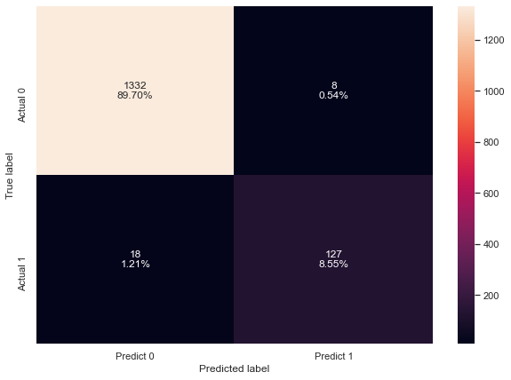

```python
make_confusion_matrix(model,y_test)
plt.savefig('CMatx_Test.png')
plt.show()
```

```python
y_train.value_counts(1) #this would return the relative frequency by dividing all values by the sum of values.
#y_train.value_counts(True)
```

```
0   0.90
1   0.10
Name: Personal_Loan, dtype: float64
```

### Insights:

- **True Positives:**
  - Reality: A customer took the loan
  - Model predicted: The customer will contribute to revenue and profit
  - Outcome: The model is good.
- **True Negatives:**
  - Reality: A customer did NOT take the loan.
  - Model predicted: The customer will NOT contribute to revenue and profit
  - Outcome: The business is unaffected.
- **False Positives:**
  - Reality: A customer did NOT take a loan.
  - Model predicted: The customer will contribute to revenue and profit
  - Outcome: The team which is targeting the potential customers will be wasting their resources on the people/customers who will not be contributing to the revenue.
- **False Negatives:**
  - Reality: A customer took the loan.
  - Model predicted: The customer will NOT contribute to revenue and profit
  - Outcome: The potential customer is missed by the sales/marketing team, the team could have offered the potential customer some discount or loyalty card to make the customer come again to purchase. (Customer retention will get affected.)
- In this case, not being able to identify a potential customer is the biggest loss we can face. Hence, recall is the right metric to check the performance of the model.

$ Recall = \dfrac{TP}{TP+FN} $

```python
##  Function to calculate recall score
def get_recall_score(model):
    '''
    model : classifier to predict values of X

    '''
    pred_train = model.predict(X_train)
    pred_test = model.predict(X_test)
    print("Recall on training set : ",metrics.recall_score(y_train,pred_train))
    print("Recall on test set : ",metrics.recall_score(y_test,pred_test))
```

```python
get_recall_score(model)
```

```
Recall on training set :  1.0
Recall on test set :  0.8758620689655172
```

- There is a relative disparity in performance of model on training set and test set, which suggests that the model is overfiiting.

## Visualizing the Decision Tree

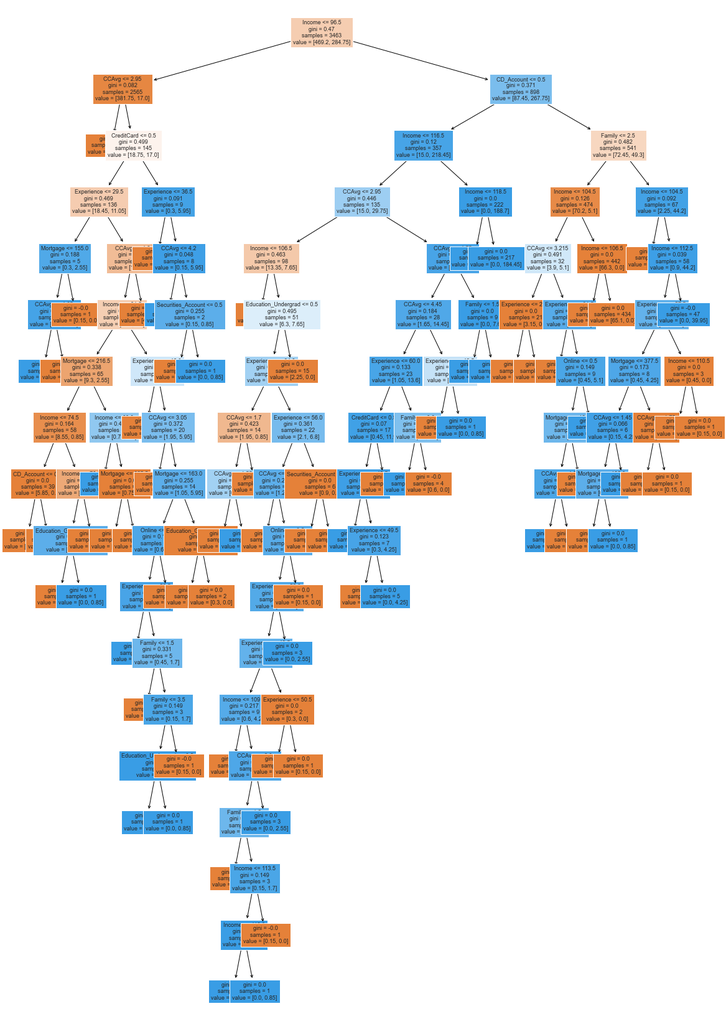

```python
plt.figure(figsize=(20,30))
out = tree.plot_tree(model,feature_names=feature_names,filled=True,fontsize=9,node_ids=False,class_names=None,)
#below code will add arrows to the decision tree split if they are missing
for o in out:
     arrow = o.arrow_patch
     if arrow is not None:
        arrow.set_edgecolor('black')
        arrow.set_linewidth(1)
plt.savefig('CART_Plt.png')
plt.show()
```

```python
# Text report showing the rules of a decision tree -

print(tree.export_text(model,feature_names=feature_names,show_weights=True))
```

```
|--- Income <= 96.50
|   |--- CCAvg <= 2.95
|   |   |--- weights: [363.00, 0.00] class: 0
|   |--- CCAvg >  2.95
|   |   |--- CreditCard <= 0.50
|   |   |   |--- Experience <= 29.50
|   |   |   |   |--- Mortgage <= 155.00
|   |   |   |   |   |--- CCAvg <= 4.65
|   |   |   |   |   |   |--- weights: [0.00, 2.55] class: 1
|   |   |   |   |   |--- CCAvg >  4.65
|   |   |   |   |   |   |--- weights: [0.15, 0.00] class: 0
|   |   |   |   |--- Mortgage >  155.00
|   |   |   |   |   |--- weights: [0.15, 0.00] class: 0
|   |   |   |--- Experience >  29.50
|   |   |   |   |--- CCAvg <= 4.20
|   |   |   |   |   |--- Income <= 81.50
|   |   |   |   |   |   |--- Mortgage <= 216.50
|   |   |   |   |   |   |   |--- Income <= 74.50
|   |   |   |   |   |   |   |   |--- CD_Account <= 0.50
|   |   |   |   |   |   |   |   |   |--- weights: [3.75, 0.00] class: 0
|   |   |   |   |   |   |   |   |--- CD_Account >  0.50
|   |   |   |   |   |   |   |   |   |--- weights: [2.10, 0.00] class: 0
|   |   |   |   |   |   |   |--- Income >  74.50
|   |   |   |   |   |   |   |   |--- Income <= 76.50
|   |   |   |   |   |   |   |   |   |--- Education_Graduate <= 0.50
|   |   |   |   |   |   |   |   |   |   |--- weights: [0.15, 0.00] class: 0
|   |   |   |   |   |   |   |   |   |--- Education_Graduate >  0.50
|   |   |   |   |   |   |   |   |   |   |--- weights: [0.00, 0.85] class: 1
|   |   |   |   |   |   |   |   |--- Income >  76.50
|   |   |   |   |   |   |   |   |   |--- weights: [2.55, 0.00] class: 0
|   |   |   |   |   |   |--- Mortgage >  216.50
|   |   |   |   |   |   |   |--- Income <= 68.00
|   |   |   |   |   |   |   |   |--- weights: [0.00, 1.70] class: 1
|   |   |   |   |   |   |   |--- Income >  68.00
|   |   |   |   |   |   |   |   |--- Mortgage <= 225.50
|   |   |   |   |   |   |   |   |   |--- weights: [0.15, 0.00] class: 0
|   |   |   |   |   |   |   |   |--- Mortgage >  225.50
|   |   |   |   |   |   |   |   |   |--- weights: [0.60, 0.00] class: 0
|   |   |   |   |   |--- Income >  81.50
|   |   |   |   |   |   |--- Experience <= 46.00
```

[output cut: 138 more lines]

```
|   |   |   |   |   |   |   |   |   |--- weights: [0.00, 0.85] class: 1
|   |   |   |   |   |   |   |--- CCAvg >  1.45
|   |   |   |   |   |   |   |   |--- weights: [0.00, 3.40] class: 1
|   |   |   |   |   |   |--- Mortgage >  377.50
|   |   |   |   |   |   |   |--- CCAvg <= 1.75
|   |   |   |   |   |   |   |   |--- weights: [0.15, 0.00] class: 0
|   |   |   |   |   |   |   |--- CCAvg >  1.75
|   |   |   |   |   |   |   |   |--- weights: [0.15, 0.00] class: 0
|   |   |   |   |   |--- Experience >  57.50
|   |   |   |   |   |   |--- Income <= 110.50
|   |   |   |   |   |   |   |--- weights: [0.30, 0.00] class: 0
|   |   |   |   |   |   |--- Income >  110.50
|   |   |   |   |   |   |   |--- weights: [0.15, 0.00] class: 0
|   |   |   |   |--- Income >  112.50
|   |   |   |   |   |--- weights: [0.00, 39.95] class: 1
```

```python
# importance of features in the tree building ( The importance of a feature is computed as the
#(normalized) total reduction of the criterion brought by that feature. It is also known as the Gini importance )

print (pd.DataFrame(model.feature_importances_, columns = ["Imp"], index = X_train.columns).sort_values(by = 'Imp', ascending = False))
```

```
                      Imp
Income               0.60
Family               0.13
Education_Undergrad  0.13
CCAvg                0.08
Age                  0.03
CD_Account_1         0.01
Mortgage             0.01
CreditCard_1         0.00
Securities_Account_1 0.00
Education_Graduate   0.00
Online_1             0.00
const                0.00
```

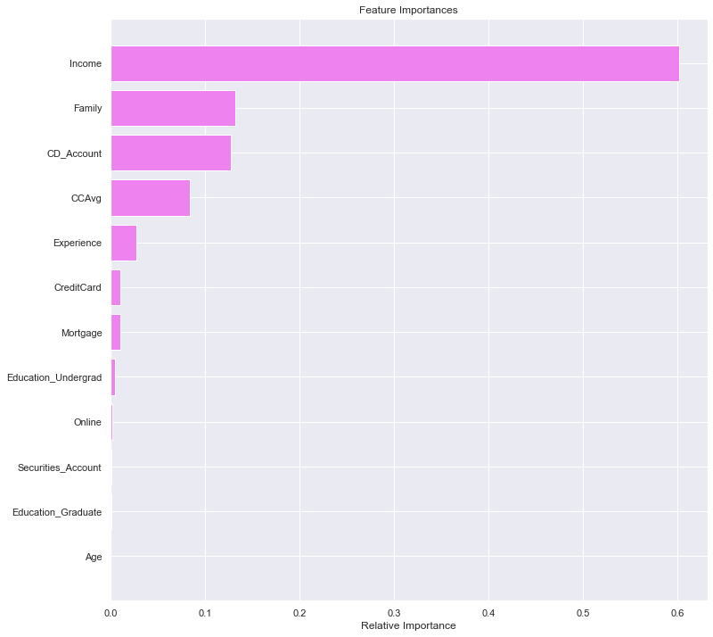

```python
#This would create a bar plot of features by importance
importances = model.feature_importances_ # gets all variables
indices = np.argsort(importances)

plt.figure(figsize=(12,12))
plt.title('Feature Importances')
plt.barh(range(len(indices)), importances[indices], color='violet', align='center')
plt.yticks(range(len(indices)), [feature_names[i] for i in indices])
plt.xlabel('Relative Importance')
plt.savefig('DT1_Features_Plt.png')
plt.show()
```

- According to the decision tree model, Income is the most important variable for predicting the Loan Purchase.

**The tree above is very complex and difficult to interpret.**

## Reducing over fitting

### Using GridSearch for Hyperparameter tuning of our tree model

- Hyperparameter tuning is also tricky in the sense that there is no direct way to calculate how a change in the hyperparameter value will reduce the loss of your model, so we usually resort to experimentation. i.e we'll use Grid search
- Grid search is a tuning technique that attempts to compute the optimum values of hyperparameters.
- It is an exhaustive search that is performed on a the specific parameter values of a model.
- The parameters of the estimator/model used to apply these methods are optimized by cross-validated grid-search over a parameter grid.

```python
from sklearn.model_selection import GridSearchCV
```

```python
# Choose the type of classifier.
estimator = DecisionTreeClassifier(random_state=1, class_weight = {0:.15,1:.85})

# Grid of parameters to choose from
parameters = {
            'max_depth': np.arange(1,10),
            'criterion': ['entropy','gini'],
            'splitter': ['best','random'],
            'min_impurity_decrease': [0.000001,0.00001,0.0001],
            'max_features': ['log2','sqrt']
             }

# Type of scoring used to compare parameter combinations
scorer = metrics.make_scorer(metrics.recall_score) # wraps scoring functions for use in GridSearchCV

# Run the grid search
grid_obj = GridSearchCV(estimator, parameters, scoring=scorer, cv=5)
grid_obj = grid_obj.fit(X_train, y_train)

# Set the clf to the best combination of parameters
estimator = grid_obj.best_estimator_

# Fit the best algorithm to the data.
estimator.fit(X_train, y_train)
```

```
DecisionTreeClassifier(class_weight={0: 0.15, 1: 0.85}, max_depth=3,
                       max_features='log2', min_impurity_decrease=1e-06,
                       random_state=1)
```

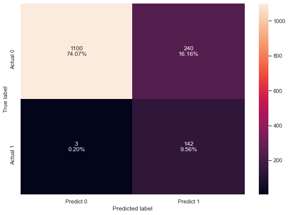

```python
make_confusion_matrix(estimator,y_test)
plt.savefig('CM_HP_Test.png')
plt.show()
```

```python
get_recall_score(estimator)
```

```
Recall on training set :  0.9970149253731343
Recall on test set :  0.9793103448275862
```

**Recall has been regularised for the Train set and improved for the test set after hyperparameter tuning and we have a generalized model.**

## Visualizing the Decision Tree

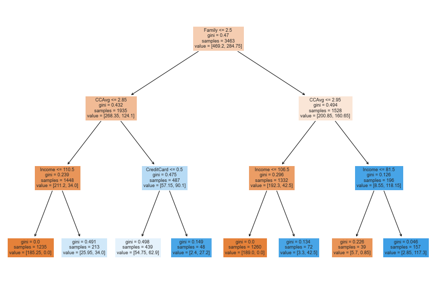

```python
plt.figure(figsize=(15,10))
out = tree.plot_tree(estimator,feature_names=feature_names,filled=True,fontsize=9,node_ids=False,class_names=None)
for o in out:
    arrow = o.arrow_patch
    if arrow is not None:
        arrow.set_edgecolor('black')
        arrow.set_linewidth(1)
plt.savefig('CART_Plt1.png')
plt.show()
```

```python
# Text report showing the rules of a decision tree -

print(tree.export_text(estimator,feature_names=feature_names,show_weights=True))
```

```
|--- Family <= 2.50
|   |--- CCAvg <= 2.85
|   |   |--- Income <= 110.50
|   |   |   |--- weights: [185.25, 0.00] class: 0
|   |   |--- Income >  110.50
|   |   |   |--- weights: [25.95, 34.00] class: 1
|   |--- CCAvg >  2.85
|   |   |--- CreditCard <= 0.50
|   |   |   |--- weights: [54.75, 62.90] class: 1
|   |   |--- CreditCard >  0.50
|   |   |   |--- weights: [2.40, 27.20] class: 1
|--- Family >  2.50
|   |--- CCAvg <= 2.95
|   |   |--- Income <= 106.50
|   |   |   |--- weights: [189.00, 0.00] class: 0
|   |   |--- Income >  106.50
|   |   |   |--- weights: [3.30, 42.50] class: 1
|   |--- CCAvg >  2.95
|   |   |--- Income <= 81.50
|   |   |   |--- weights: [5.70, 0.85] class: 0
|   |   |--- Income >  81.50
|   |   |   |--- weights: [2.85, 117.30] class: 1
```

```python
# importance of features in the tree building ( The importance of a feature is computed as the
#(normalized) total reduction of the 'criterion' brought by that feature. It is also known as the Gini importance )

print (pd.DataFrame(estimator.feature_importances_, columns = ["Imp"], index = X_train.columns).sort_values(by = 'Imp', ascending = False))

#Here we will see that importance of features has increased
```

```
                      Imp
CCAvg                0.54
Income               0.41
CD_Account_1         0.03
Family               0.02
const                0.00
Age                  0.00
Mortgage             0.00
Education_Graduate   0.00
Education_Undergrad  0.00
Securities_Account_1 0.00
Online_1             0.00
CreditCard_1         0.00
```

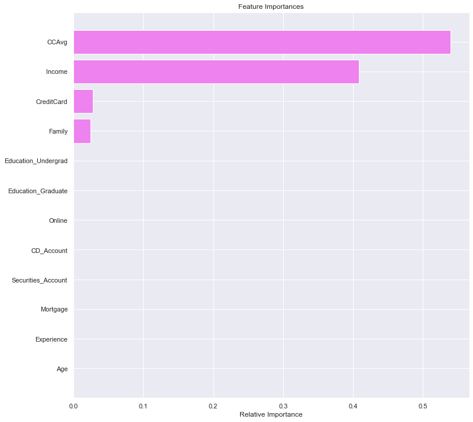

```python
importances = estimator.feature_importances_
indices = np.argsort(importances)

plt.figure(figsize=(12,12))
plt.title('Feature Importances')
plt.barh(range(len(indices)), importances[indices], color='violet', align='center')#barh - Horizontal barchart
plt.yticks(range(len(indices)), [feature_names[i] for i in indices])
plt.xlabel('Relative Importance')
plt.savefig('DT2_Features_Plt.png')
plt.show()
```

## Cost Complexity Pruning

The `DecisionTreeClassifier` provides parameters such as `min_samples_leaf` and `max_depth` to prevent a tree from overfiting. Cost complexity pruning provides another option to control the size of a tree. In `DecisionTreeClassifier`, this pruning technique is parameterized by the cost complexity parameter, `ccp_alpha`. Greater values of `ccp_alpha` increase the number of nodes pruned. Here we only show the effect of `ccp_alpha` on regularizing the trees and how to choose a `ccp_alpha` based on validation scores. Simply put the complexity parameter (cp) is used to control the size of the decision tree and to select the optimal tree size.

## Total impurity of leaves vs effective alphas of pruned tree

Minimal cost complexity pruning recursively finds the node with the "weakest link". The weakest link is characterized by an effective alpha, where the nodes with the smallest effective alpha are pruned first. To get an idea of what values of `ccp_alpha` could be appropriate, scikit-learn provides `DecisionTreeClassifier.cost_complexity_pruning_path` that returns the effective alphas and the corresponding total leaf impurities at each step of the pruning process. As alpha increases, more of the tree is pruned, which increases the total impurity of its leaves.

```python
clf = DecisionTreeClassifier(random_state=1,class_weight = {0:0.15,1:0.85})

path = clf.cost_complexity_pruning_path(X_train, y_train)
ccp_alphas, impurities = path.ccp_alphas, path.impurities
```

```python
pd.DataFrame(path)
```

|  | ccp_alphas | impurities |
| --- | --- | --- |
| 0 | 0.00 | -0.00 |
| 1 | 0.00 | -0.00 |
| 2 | 0.00 | -0.00 |
| 3 | 0.00 | -0.00 |
| 4 | 0.00 | -0.00 |
| 5 | 0.00 | -0.00 |
| 6 | 0.00 | -0.00 |
| 7 | 0.00 | -0.00 |
| 8 | 0.00 | -0.00 |
| 9 | 0.00 | -0.00 |
| 10 | 0.00 | -0.00 |
| 11 | 0.00 | -0.00 |
| 12 | 0.00 | -0.00 |
| 13 | 0.00 | -0.00 |
| 14 | 0.00 | 0.00 |
| 15 | 0.00 | 0.00 |
| 16 | 0.00 | 0.00 |
| 17 | 0.00 | 0.00 |
| 18 | 0.00 | 0.00 |
| 19 | 0.00 | 0.01 |
| 20 | 0.00 | 0.01 |
| 21 | 0.00 | 0.01 |
| 22 | 0.00 | 0.01 |
| 23 | 0.00 | 0.01 |
| 24 | 0.00 | 0.01 |
| 25 | 0.00 | 0.01 |
| 26 | 0.00 | 0.01 |
| 27 | 0.00 | 0.01 |
| 28 | 0.00 | 0.02 |
| 29 | 0.00 | 0.02 |
| 30 | 0.00 | 0.02 |
| 31 | 0.00 | 0.02 |
| 32 | 0.00 | 0.02 |
| 33 | 0.00 | 0.02 |
| 34 | 0.00 | 0.03 |
| 35 | 0.00 | 0.03 |
| 36 | 0.00 | 0.03 |
| 37 | 0.00 | 0.04 |
| 38 | 0.00 | 0.04 |
| 39 | 0.00 | 0.04 |
| 40 | 0.00 | 0.05 |
| 41 | 0.00 | 0.05 |
| 42 | 0.01 | 0.06 |
| 43 | 0.01 | 0.07 |
| 44 | 0.01 | 0.08 |
| 45 | 0.02 | 0.10 |
| 46 | 0.06 | 0.16 |
| 47 | 0.06 | 0.22 |
| 48 | 0.25 | 0.47 |

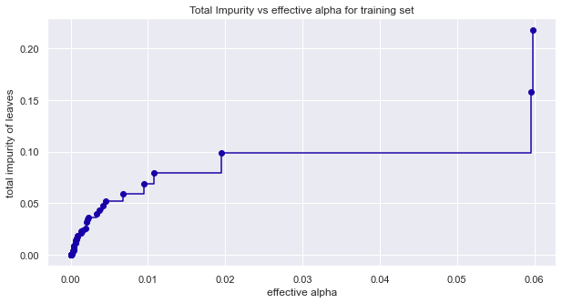

```python
fig, ax = plt.subplots(figsize=(10,5))
ax.plot(ccp_alphas[:-1], impurities[:-1], marker='o', drawstyle="steps-post")
ax.set_xlabel("effective alpha")
ax.set_ylabel("total impurity of leaves")
ax.set_title("Total Impurity vs effective alpha for training set")
plt.savefig('CC_Alpha.png')
plt.show()
```

Next, we train a decision tree using the effective alphas. The last value in `ccp_alphas` is the alpha value that prunes the whole tree, leaving the tree, `clfs[-1]`, with one node.

```python
clfs = []
for ccp_alpha in ccp_alphas:
    clf = DecisionTreeClassifier(random_state=1, ccp_alpha=ccp_alpha,class_weight = {0:0.15,1:0.85})
    clf.fit(X_train, y_train)
    clfs.append(clf)
print("Number of nodes in the last tree is: {} with ccp_alpha: {}".format(
      clfs[-1].tree_.node_count, ccp_alphas[-1]))
```

```
Number of nodes in the last tree is: 1 with ccp_alpha: 0.25203583584710654
```

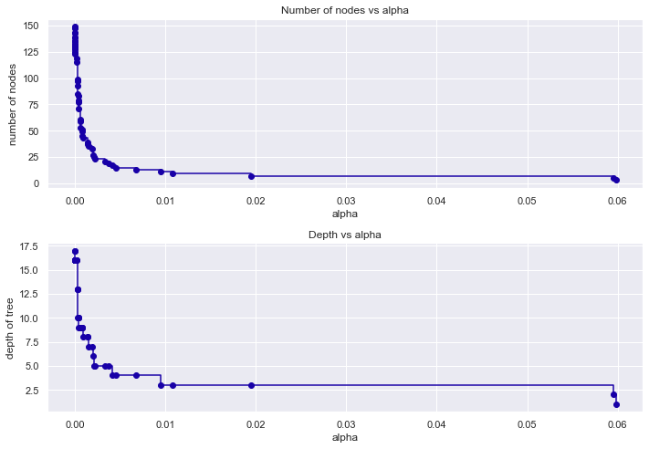

```python
#Let's look at the number of nodes vs alpha and the depth of tree vs alpha

#For the remainder, we remove the last element in ``clfs`` and ``ccp_alphas``, because it is the trivial tree with only one
#node. Here we show that the number of nodes and tree depth decreases as alpha increases.

clfs = clfs[:-1]
ccp_alphas = ccp_alphas[:-1]

node_counts = [clf.tree_.node_count for clf in clfs]
depth = [clf.tree_.max_depth for clf in clfs]
fig, ax = plt.subplots(2, 1,figsize=(10,7))
ax[0].plot(ccp_alphas, node_counts, marker='o', drawstyle="steps-post")
ax[0].set_xlabel("alpha")
ax[0].set_ylabel("number of nodes")
ax[0].set_title("Number of nodes vs alpha")
ax[1].plot(ccp_alphas, depth, marker='o', drawstyle="steps-post")
ax[1].set_xlabel("alpha")
ax[1].set_ylabel("depth of tree")
ax[1].set_title("Depth vs alpha")
fig.tight_layout()
```

```python
recall_train=[]
for clf in clfs:
    pred_train3=clf.predict(X_train)
    values_train=metrics.recall_score(y_train,pred_train3)
    recall_train.append(values_train)
```

```python
recall_test=[]
for clf in clfs:
    pred_test3=clf.predict(X_test)
    values_test=metrics.recall_score(y_test,pred_test3)
    recall_test.append(values_test)
```

```python
train_scores = [clf.score(X_train, y_train) for clf in clfs]
test_scores = [clf.score(X_test, y_test) for clf in clfs]
```

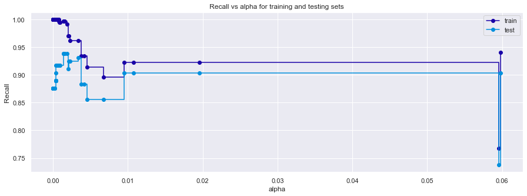

```python
fig, ax = plt.subplots(figsize=(15,5))
ax.set_xlabel("alpha")
ax.set_ylabel("Recall")
ax.set_title("Recall vs alpha for training and testing sets")
ax.plot(ccp_alphas, recall_train, marker='o', label="train",
        drawstyle="steps-post",)
ax.plot(ccp_alphas, recall_test, marker='o', label="test",
        drawstyle="steps-post")
ax.legend()
plt.show()
```

```python
# creating the model where we get highest train and test recall
index_best_model = np.argmax(recall_test)
best_model = clfs[index_best_model]
print(best_model)
```

```
DecisionTreeClassifier(ccp_alpha=0.0013742458218219838,
                       class_weight={0: 0.15, 1: 0.85}, random_state=1)
```

```python
best_model.fit(X_train, y_train)
```

```
DecisionTreeClassifier(ccp_alpha=0.0013742458218219838,
                       class_weight={0: 0.15, 1: 0.85}, random_state=1)
```

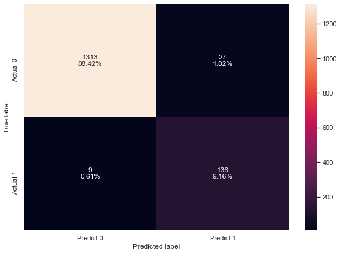

```python
make_confusion_matrix(best_model,y_test)
```

```python
get_recall_score(best_model)
```

```
Recall on training set :  0.9970149253731343
Recall on test set :  0.9379310344827586
```

**This model might be returning a high Recall but in practice, it won't target the potential loan purchasers**

## Visualizing the Decision Tree

[figure not shown]

```python
plt.figure(figsize=(5,5))

out = tree.plot_tree(best_model,feature_names=feature_names,filled=True,fontsize=9,node_ids=False,class_names=None)
for o in out:
    arrow = o.arrow_patch
    if arrow is not None:
        arrow.set_edgecolor('black')
        arrow.set_linewidth(1)
plt.savefig('CART2_Plt.png')
plt.show()
```

**Creating model with 0.004 ccp_alpha**

```python
best_model2 = DecisionTreeClassifier(ccp_alpha=0.00365, class_weight={0: 0.15, 1: 0.85}, random_state=1)
best_model2.fit(X_train, y_train)
```

```
DecisionTreeClassifier(ccp_alpha=0.00365, class_weight={0: 0.15, 1: 0.85},
                       random_state=1)
```

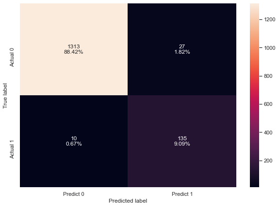

```python
make_confusion_matrix(best_model2,y_test)
```

```python
get_recall_score(best_model2)
```

```
Recall on training set :  0.9611940298507463
Recall on test set :  0.9310344827586207
```

## Visualizing the Decision Tree

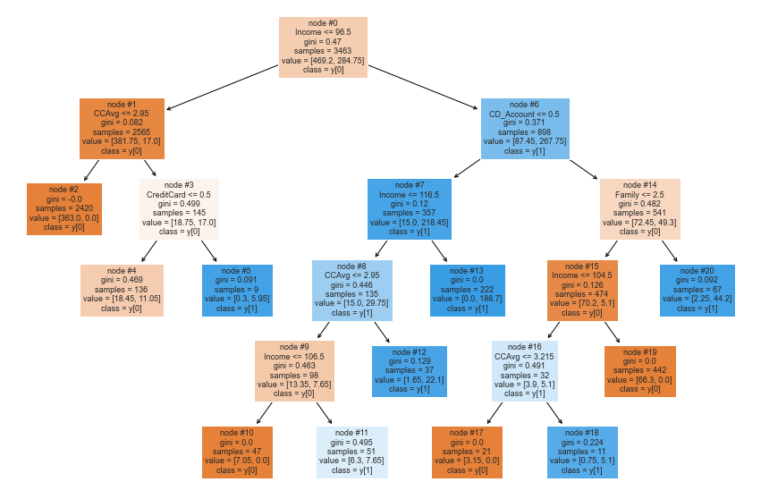

```python
plt.figure(figsize=(15,10))

out = tree.plot_tree(best_model2,feature_names=feature_names,filled=True,fontsize=9,node_ids=True,class_names=True)
for o in out:
    arrow = o.arrow_patch
    if arrow is not None:
        arrow.set_edgecolor('black')
        arrow.set_linewidth(1)
plt.show()
```

```python
# Text report showing the rules of a decision tree -

print(tree.export_text(best_model2,feature_names=feature_names,show_weights=True))
```

```
|--- Income <= 96.50
|   |--- CCAvg <= 2.95
|   |   |--- weights: [363.00, 0.00] class: 0
|   |--- CCAvg >  2.95
|   |   |--- CreditCard <= 0.50
|   |   |   |--- weights: [18.45, 11.05] class: 0
|   |   |--- CreditCard >  0.50
|   |   |   |--- weights: [0.30, 5.95] class: 1
|--- Income >  96.50
|   |--- CD_Account <= 0.50
|   |   |--- Income <= 116.50
|   |   |   |--- CCAvg <= 2.95
|   |   |   |   |--- Income <= 106.50
|   |   |   |   |   |--- weights: [7.05, 0.00] class: 0
|   |   |   |   |--- Income >  106.50
|   |   |   |   |   |--- weights: [6.30, 7.65] class: 1
|   |   |   |--- CCAvg >  2.95
|   |   |   |   |--- weights: [1.65, 22.10] class: 1
|   |   |--- Income >  116.50
|   |   |   |--- weights: [0.00, 188.70] class: 1
|   |--- CD_Account >  0.50
|   |   |--- Family <= 2.50
|   |   |   |--- Income <= 104.50
|   |   |   |   |--- CCAvg <= 3.21
|   |   |   |   |   |--- weights: [3.15, 0.00] class: 0
|   |   |   |   |--- CCAvg >  3.21
|   |   |   |   |   |--- weights: [0.75, 5.10] class: 1
|   |   |   |--- Income >  104.50
|   |   |   |   |--- weights: [66.30, 0.00] class: 0
|   |   |--- Family >  2.50
|   |   |   |--- weights: [2.25, 44.20] class: 1
```

```python
# importance of features in the tree building ( The importance of a feature is computed as the
#(normalized) total reduction of the 'criterion' brought by that feature. It is also known as the Gini importance )

print (pd.DataFrame(best_model2.feature_importances_, columns = ["Imp"], index = X_train.columns).sort_values(by = 'Imp', ascending = False))
```

```
                      Imp
Income               0.64
Education_Undergrad  0.14
Family               0.14
CCAvg                0.08
CD_Account_1         0.01
const                0.00
Age                  0.00
Mortgage             0.00
Education_Graduate   0.00
Securities_Account_1 0.00
Online_1             0.00
CreditCard_1         0.00
```

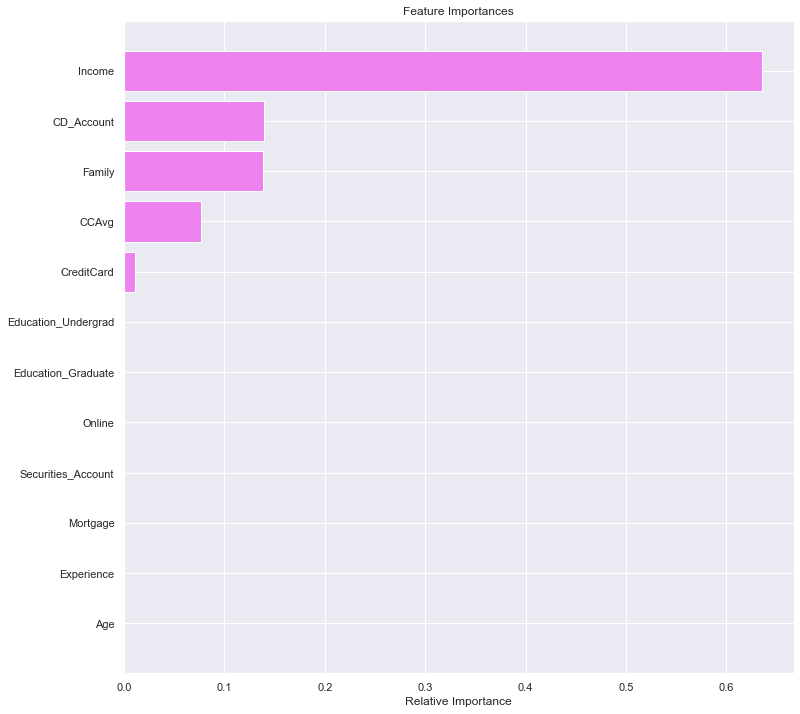

```python
importances = best_model2.feature_importances_
indices = np.argsort(importances)

plt.figure(figsize=(12,12))
plt.title('Feature Importances')
plt.barh(range(len(indices)), importances[indices], color='violet', align='center')
plt.yticks(range(len(indices)), [feature_names[i] for i in indices])
plt.xlabel('Relative Importance')
plt.savefig('FinalFeatures_plt.png')
plt.show()
```

## Comparing all the decision tree models

```python
comparison_frame = pd.DataFrame({'Model':['Logistics Regression with Sklearn','Logistics Regression with Statsmodel','Initial decision tree model','Decision tree with hyperparameter tuning',
                                          'Decision tree with post-pruning'], 'Train_Recall':[0.66,0.77,1.0,0.99,0.96], 'Test_Recall':[0.64,0.77,0.87,0.98,0.93]})
comparison_frame
```

|  | Model | Train_Recall | Test_Recall |
| --- | --- | --- | --- |
| 0 | Logistics Regression with Sklearn | 0.66 | 0.64 |
| 1 | Logistics Regression with Statsmodel | 0.77 | 0.77 |
| 2 | Initial decision tree model | 1.00 | 0.87 |
| 3 | Decision tree with hyperparameter tuning | 0.99 | 0.98 |
| 4 | Decision tree with post-pruning | 0.96 | 0.93 |

**Decision tree model with post pruning has given a very good recall score on data.**

### Recommendations

- According to the Decision Tree model -
- If a liability customer has an income less than $96,500 there's a very high chance the customer will not qualify for a personal loan offer
- If thesame customer spends on his credit card an amount in excess of $ 2,950 and a credit card greater than 0.5, then chances are that the customer will qualify for a personal loan
- However, if thesame customer, spends below $ 2,950 from his credit card, he definitely will not qualify for a loan in the new campaign
- Now, if another customer earns more than $96,500, with a Certificate of deposit greater than 0.5, and a family size of more than 2.5, then he or she definitely qualifies for a personal loan.
- It is observed that the more the customers earn with a much higher average spending on credit card, CCAvg, there is are likelihood of being granted a personal loan.
- AllLife can also employ the predictive model to predict potential personal loan customers (customers who can buy the product) and also disqualify customers wwho do not meet up with the set criteria in the Decision Tree
- The CART model can equally be used to predict customer retention and turnover
- Effective Resource allocation and management - The Prediction model equips the marketing campaign team of the much needed weapon for targeted sales of their Personal Loan offers as well as aid the MBoard and Management team of AllLife to effectively otimize cost and reduce unecessary overheads
- Increased Sales Turnover : This clearly speaks to hidden patterns and opportunities in the Decision Tree model taht enables the management take advantage of yet untapped customer brackets accross various classes in the distribution